# ASML3 Lab 3 – Full modelling exercise

## Introduction

We will continue looking at the credit dataset from the last lab and do a full analysis using the machine learning techniques that we have learned so far. Previous labs have gone a little slower and focused on detail. Today, we will dive deeper in to MLR3 and run a best-practise analysis, which may require you to spend time outside the lab to fully understand.

First, load the dataset into R:

```r
# Credit data
data("credit_data", package = "modeldata")
```

## Credit data

### Data exploration

First, one should always familiarise oneself with the data at hand. The following is probably an absolute minimum.

```r
skimr::skim(credit_data)
```

Data summary

| Name | credit_data |
| --- | --- |
| Number of rows | 4454 |
| Number of columns | 14 |
| _______________________ |  |
| Column type frequency: |  |
| factor | 5 |
| numeric | 9 |
| ________________________ |  |
| Group variables | None |

**Variable type: factor**

| skim_variable | n_missing | complete_rate | ordered | n_unique | top_counts |
| --- | --- | --- | --- | --- | --- |
| Status | 0 | 1 | FALSE | 2 | goo: 3200, bad: 1254 |
| Home | 6 | 1 | FALSE | 6 | own: 2107, ren: 973, par: 783, oth: 319 |
| Marital | 1 | 1 | FALSE | 5 | mar: 3241, sin: 977, sep: 130, wid: 67 |
| Records | 0 | 1 | FALSE | 2 | no: 3681, yes: 773 |
| Job | 2 | 1 | FALSE | 4 | fix: 2805, fre: 1024, par: 452, oth: 171 |

**Variable type: numeric**

| skim_variable | n_missing | complete_rate | mean | sd | p0 | p25 | p50 | p75 | p100 | hist |
| --- | --- | --- | --- | --- | --- | --- | --- | --- | --- | --- |
| Seniority | 0 | 1.00 | 7.99 | 8.17 | 0 | 2.00 | 5 | 12.0 | 48 | ▇▃▁▁▁ |
| Time | 0 | 1.00 | 46.44 | 14.66 | 6 | 36.00 | 48 | 60.0 | 72 | ▁▂▅▃▇ |
| Age | 0 | 1.00 | 37.08 | 10.98 | 18 | 28.00 | 36 | 45.0 | 68 | ▆▇▆▃▁ |
| Expenses | 0 | 1.00 | 55.57 | 19.52 | 35 | 35.00 | 51 | 72.0 | 180 | ▇▃▁▁▁ |
| Income | 381 | 0.91 | 141.69 | 80.75 | 6 | 90.00 | 125 | 170.0 | 959 | ▇▂▁▁▁ |
| Assets | 47 | 0.99 | 5403.98 | 11574.42 | 0 | 0.00 | 3000 | 6000.0 | 300000 | ▇▁▁▁▁ |
| Debt | 18 | 1.00 | 343.03 | 1245.99 | 0 | 0.00 | 0 | 0.0 | 30000 | ▇▁▁▁▁ |
| Amount | 0 | 1.00 | 1038.92 | 474.55 | 100 | 700.00 | 1000 | 1300.0 | 5000 | ▇▆▁▁▁ |
| Price | 0 | 1.00 | 1462.78 | 628.13 | 105 | 1117.25 | 1400 | 1691.5 | 11140 | ▇▁▁▁▁ |

The important thing to note from above is that some variables have missing values. This is common in real world datasets and so we’re going to work hard to deal with that without throwing data away.

Now some plots:

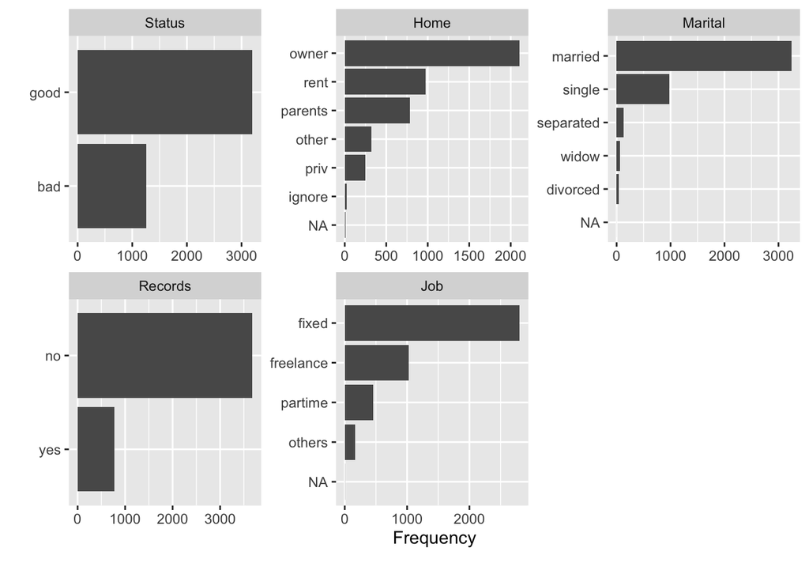

```r
DataExplorer::plot_bar(credit_data, ncol = 3)
```

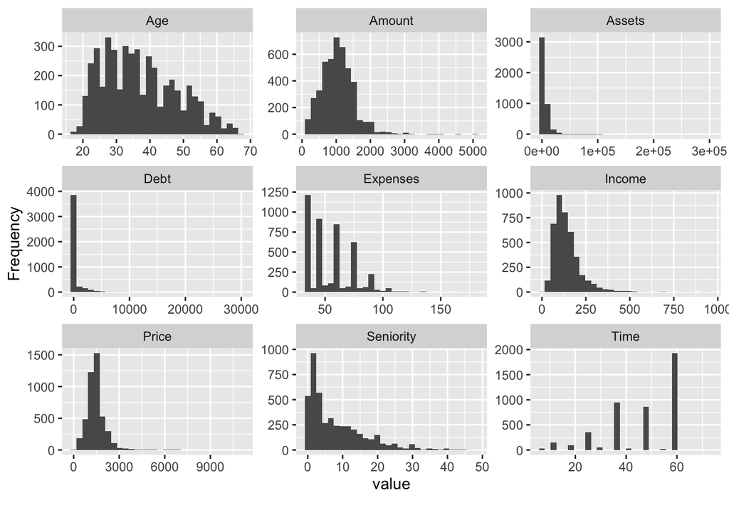

```r
DataExplorer::plot_histogram(credit_data, ncol = 3)
```

The final one splits out continuous variables by the response we are interested in modelling:

```
## Warning: Removed 446 rows containing non-finite values (stat_boxplot).
```

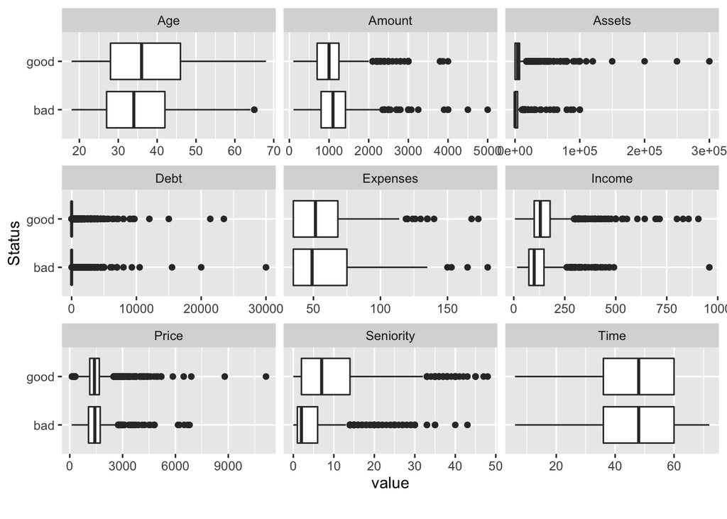

```r
DataExplorer::plot_boxplot(credit_data, by = "Status", ncol = 3)
```

### Task and resampling

First, let’s load MLR3 and all related tools, using the `mlr3verse` meta-package. We will also need the `data.table` package which is the main data structure used by MLR3 (don’t worry if you get some red text warning about OpenMP support).

```r
library("data.table")
library("mlr3verse")
```

The first job when we turn to modelling in MLR3 is always to define a task. Here, we are going to define a ‘positive’ outcome to be a loan going bad. This will be important to specify for when we assess the model performance.

```r
set.seed(212) # set seed for reproducibility
credit_task <- TaskClassif$new(id = "BankCredit",
                               backend = credit_data, # <- NB: no na.omit() this time
                               target = "Status",
                               positive = "bad")
```

Notice above that this time we did *not* remove the missing data as we did in lab 2. We’re going to handle it better this time.

Next, we want to define the resampling strategy we will use for error estimation.

```r
# Let's see what resampling strategies MLR supports

# View will open a tab where you can more easily see the detail ...
View(as.data.table(mlr_resamplings))
# ... whilst this just gives the names
mlr_resamplings
```

```
## <DictionaryResampling> with 8 stored values
## Keys: bootstrap, custom, cv, holdout, insample, loo, repeated_cv,
##   subsampling
```

```r
# To see help on any of them, prefix the key name with mlr_resamplings_
?mlr_resamplings_cv
```

Per lectures, we’ll go for cross validation, and we’ll arbitrarily choose 5 folds in this case. We first create the resampling strategy and then we ‘instantiate’ it on the task. Instantiating means that the folds get fixed: this means we can then use this object on multiple learners and know that the same set of folds have been used so that comparisons are fair.

```r
# The rsmp function constructs a resampling strategy, taking the name given
# above and allowing any options listed there to be chosen
cv5 <- rsmp("cv", folds = 5)
cv5$instantiate(credit_task)
```

### Some simple learners

We are now ready to try fitting some simple learners. Let’s remind ourselves what’s available:

```r
# View will open a tab where you can more easily see the detail ...
View(as.data.table(mlr_learners))
# ... whilst this just gives the names
mlr_learners
```

```
## <DictionaryLearner> with 51 stored values
## Keys: classif.cv_glmnet, classif.debug, classif.featureless,
##   classif.glmnet, classif.kknn, classif.lda, classif.log_reg,
##   classif.multinom, classif.naive_bayes, classif.nnet, classif.qda,
##   classif.ranger, classif.rpart, classif.svm, classif.xgboost,
##   clust.agnes, clust.ap, clust.cmeans, clust.cobweb, clust.dbscan,
##   clust.diana, clust.em, clust.fanny, clust.featureless, clust.ff,
##   clust.kkmeans, clust.kmeans, clust.MBatchKMeans, clust.meanshift,
##   clust.pam, clust.SimpleKMeans, clust.xmeans, dens.hist, dens.kde,
##   regr.cv_glmnet, regr.featureless, regr.glmnet, regr.kknn, regr.km,
##   regr.lm, regr.ranger, regr.rpart, regr.svm, regr.xgboost, surv.coxph,
##   surv.cv_glmnet, surv.glmnet, surv.kaplan, surv.ranger, surv.rpart,
##   surv.xgboost
```

```r
# Again, to see help on any of them, prefix the key name with mlr_learners_
?mlr_learners_classif.log_reg
```

In the View tab, pay particular attention to the `feature_types` and `properties` columns. This gives us information about the capabilities of different learners. For example, we know that we have `numeric` and `factor` data from the exploration above, so only those learners listing these under `feature_types` can handle our data natively — for other learners we have some work to do. Likewise, we know that we have missing values, so only those learners with `missings` listed under `properties` will handle our data without any additional work.

From the list we can see two models that support both factors and missings, so we could try these first

- `classif.featureless` is a so-called baseline classifier … it basically just predicts the most common response all the time ignoring the features! It is often a good idea to include this because if you don’t beat it then there is something very wrong!
- `classif.rpart` does classification trees using the methodology we saw in the lectures.

In both cases we’re going to ask for probabilistic prediction (the default just predicts the label)

```r
lrn_baseline <- lrn("classif.featureless", predict_type = "prob")
lrn_cart <- lrn("classif.rpart", predict_type = "prob")
```

We can see if these have any options we can change too:

```r
# You will need to copy these to the R console to see the output properly
lrn_baseline$param_set
```

```
## <ParamSet>
##        id    class lower upper                      levels default value
## 1: method ParamFct    NA    NA mode,sample,weighted.sample    mode  mode
```

```r
lrn_cart$param_set
```

```
## <ParamSet>
##                 id    class lower upper      levels        default value
##  1:       minsplit ParamInt     1   Inf                         20
##  2:      minbucket ParamInt     1   Inf             <NoDefault[3]>
##  3:             cp ParamDbl     0     1                       0.01
##  4:     maxcompete ParamInt     0   Inf                          4
##  5:   maxsurrogate ParamInt     0   Inf                          5
##  6:       maxdepth ParamInt     1    30                         30
##  7:   usesurrogate ParamInt     0     2                          2
##  8: surrogatestyle ParamInt     0     1                          0
##  9:           xval ParamInt     0   Inf                         10     0
## 10:     keep_model ParamLgl    NA    NA  TRUE,FALSE          FALSE
```

Let’s now fit these learners using cross-validation to determine the accuracy.

```r
res_baseline <- resample(credit_task, lrn_baseline, cv5, store_models = TRUE)
```

```
## INFO  [12:03:47.241] [mlr3]  Applying learner 'classif.featureless' on task 'BankCredit' (iter 2/5)
## INFO  [12:03:47.291] [mlr3]  Applying learner 'classif.featureless' on task 'BankCredit' (iter 1/5)
## INFO  [12:03:47.310] [mlr3]  Applying learner 'classif.featureless' on task 'BankCredit' (iter 5/5)
## INFO  [12:03:47.323] [mlr3]  Applying learner 'classif.featureless' on task 'BankCredit' (iter 4/5)
## INFO  [12:03:47.334] [mlr3]  Applying learner 'classif.featureless' on task 'BankCredit' (iter 3/5)
```

```r
res_cart <- resample(credit_task, lrn_cart, cv5, store_models = TRUE)
```

```
## INFO  [12:03:47.514] [mlr3]  Applying learner 'classif.rpart' on task 'BankCredit' (iter 1/5)
## INFO  [12:03:47.576] [mlr3]  Applying learner 'classif.rpart' on task 'BankCredit' (iter 5/5)
## INFO  [12:03:47.621] [mlr3]  Applying learner 'classif.rpart' on task 'BankCredit' (iter 4/5)
## INFO  [12:03:47.655] [mlr3]  Applying learner 'classif.rpart' on task 'BankCredit' (iter 3/5)
## INFO  [12:03:47.689] [mlr3]  Applying learner 'classif.rpart' on task 'BankCredit' (iter 2/5)
```

```r
# Look at accuracy
res_baseline$aggregate()
```

```
## classif.ce
##  0.2815415
```

```r
res_cart$aggregate()
```

```
## classif.ce
##  0.2263146
```

When we want to do multiple models it is slightly more convenient to use the benchmark function to run them all:

```r
res <- benchmark(data.table(
  task       = list(credit_task),
  learner    = list(lrn_baseline,
                    lrn_cart),
  resampling = list(cv5)
), store_models = TRUE)
```

```
## INFO  [12:03:47.835] [mlr3]  Benchmark with 10 resampling iterations
## INFO  [12:03:47.845] [mlr3]  Applying learner 'classif.rpart' on task 'BankCredit' (iter 4/5)
## INFO  [12:03:47.899] [mlr3]  Applying learner 'classif.rpart' on task 'BankCredit' (iter 2/5)
## INFO  [12:03:47.934] [mlr3]  Applying learner 'classif.rpart' on task 'BankCredit' (iter 1/5)
## INFO  [12:03:47.971] [mlr3]  Applying learner 'classif.featureless' on task 'BankCredit' (iter 4/5)
## INFO  [12:03:47.981] [mlr3]  Applying learner 'classif.rpart' on task 'BankCredit' (iter 3/5)
## INFO  [12:03:48.020] [mlr3]  Applying learner 'classif.featureless' on task 'BankCredit' (iter 1/5)
## INFO  [12:03:48.031] [mlr3]  Applying learner 'classif.featureless' on task 'BankCredit' (iter 5/5)
## INFO  [12:03:48.043] [mlr3]  Applying learner 'classif.featureless' on task 'BankCredit' (iter 2/5)
## INFO  [12:03:48.055] [mlr3]  Applying learner 'classif.featureless' on task 'BankCredit' (iter 3/5)
## INFO  [12:03:48.066] [mlr3]  Applying learner 'classif.rpart' on task 'BankCredit' (iter 5/5)
## INFO  [12:03:48.107] [mlr3]  Finished benchmark
```

```r
res
```

```
## <BenchmarkResult> of 10 rows with 2 resampling runs
##  nr    task_id          learner_id resampling_id iters warnings errors
##   1 BankCredit classif.featureless            cv     5        0      0
##   2 BankCredit       classif.rpart            cv     5        0      0
```

```r
res$aggregate()
```

| nr | resample_result | task_id | learner_id | resampling_id | iters | classif.ce |
| --- | --- | --- | --- | --- | --- | --- |
| 1 |  | BankCredit | classif.featureless | cv | 5 | 0.2815415 |
| 2 |  | BankCredit | classif.rpart | cv | 5 | 0.2263146 |

What is `classif.ce`? It is the mean misclassification error as defined in lectures. Note that the error in the baseline classifier is only 0.282! So this gives us an idea of what we need to beat (we might have expected 0.5, but this is an imbalanced dataset as is often the case with real data).

We can get many other error measures:

```r
# View will open a tab where you can more easily see the detail ...
View(as.data.table(mlr_measures))
# ... whilst this just gives the names
mlr_measures
```

```
## <DictionaryMeasure> with 102 stored values
## Keys: classif.acc, classif.auc, classif.bacc, classif.bbrier,
##   classif.ce, classif.costs, classif.dor, classif.fbeta, classif.fdr,
##   classif.fn, classif.fnr, classif.fomr, classif.fp, classif.fpr,
##   classif.logloss, classif.mbrier, classif.mcc, classif.npv,
##   classif.ppv, classif.prauc, classif.precision, classif.recall,
##   classif.sensitivity, classif.specificity, classif.tn, classif.tnr,
##   classif.tp, classif.tpr, clust.ch, clust.db, clust.dunn,
##   clust.silhouette, debug, dens.logloss, oob_error, regr.bias,
##   regr.ktau, regr.mae, regr.mape, regr.maxae, regr.medae, regr.medse,
##   regr.mse, regr.msle, regr.pbias, regr.rae, regr.rmse, regr.rmsle,
##   regr.rrse, regr.rse, regr.rsq, regr.sae, regr.smape, regr.srho,
##   regr.sse, selected_features, surv.beggC, surv.brier,
##   surv.calib_alpha, surv.calib_beta, surv.chambless_auc,
##   surv.chamblessAUC, surv.cindex, surv.gonenC, surv.graf, surv.grafSE,
##   surv.harrellC, surv.hung_auc, surv.hungAUC, surv.intlogloss,
##   surv.intloglossSE, surv.logloss, surv.loglossSE, surv.mae,
##   surv.maeSE, surv.mse, surv.mseSE, surv.nagelk_r2, surv.nagelkR2,
##   surv.oquigley_r2, surv.oquigleyR2, surv.rmse, surv.rmseSE,
##   surv.schmid, surv.song_auc, surv.song_tnr, surv.song_tpr,
##   surv.songAUC, surv.songTNR, surv.songTPR, surv.uno_auc, surv.uno_tnr,
##   surv.uno_tpr, surv.unoAUC, surv.unoC, surv.unoTNR, surv.unoTPR,
##   surv.xu_r2, surv.xuR2, time_both, time_predict, time_train
```

```r
# Again, to see help on any of them, prefix the key name with mlr_measures_
?mlr_measures_classif.ce
```

We can request the benchmark to show us multiple of these measures:

```r
res$aggregate(list(msr("classif.ce"),
                   msr("classif.acc"),
                   msr("classif.auc"),
                   msr("classif.fpr"),
                   msr("classif.fnr")))
```

| nr | resample_result | task_id | learner_id | resampling_id | iters | classif.ce | classif.acc | classif.auc | classif.fpr | classif.fnr |
| --- | --- | --- | --- | --- | --- | --- | --- | --- | --- | --- |
| 1 |  | BankCredit | classif.featureless | cv | 5 | 0.2815415 | 0.7184585 | 0.5000000 | 0.00000000 | 1.0000000 |
| 2 |  | BankCredit | classif.rpart | cv | 5 | 0.2263146 | 0.7736854 | 0.7304518 | 0.08655726 | 0.5835342 |

### Advanced look at models within

We can examine in depth the results by getting out the models fitted in each fold:

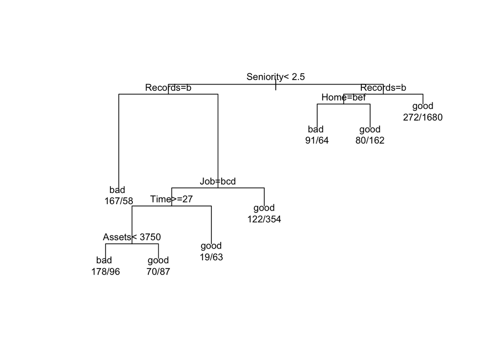

```r
# eg get the trees (2nd model fitted), by asking for second set of resample
# results
trees <- res$resample_result(2)

# Then, let's look at the tree from first CV iteration, for example:
tree1 <- trees$learners[[1]]

# This is a fitted rpart object, so we can look at the model within
tree1_rpart <- tree1$model

# If you look in the rpart package documentation, it tells us how to plot the
# tree that was fitted
plot(tree1_rpart, compress = TRUE, margin = 0.1)
text(tree1_rpart, use.n = TRUE, cex = 0.8)
```

We can see the other trees too. Change the 5 in double brackets [[]] below to other values from 1 to 5 to see the model from each round of cross validation.

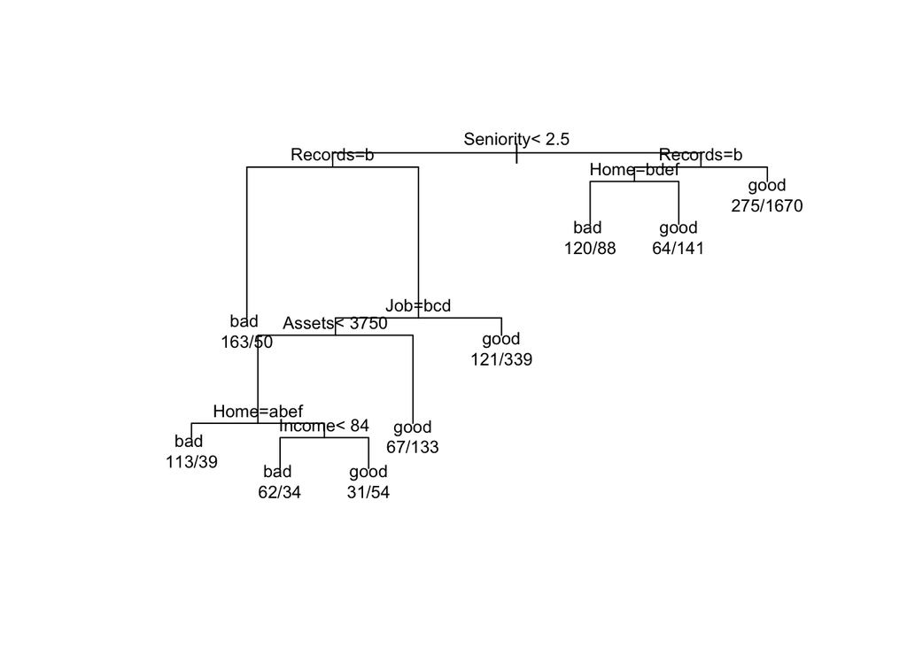

```r
plot(res$resample_result(2)$learners[[5]]$model, compress = TRUE, margin = 0.1)
text(res$resample_result(2)$learners[[5]]$model, use.n = TRUE, cex = 0.8)
```

It may be that these trees need to be pruned. To do this, we would need to enable the cross-validation option to `rpart` in the learner. We can fit this individually and make a selection for the cost penalty (see alpha in lectures), before then setting this value when benchmarking (NOTE: this is not quite optimal but MLR3 doesn’t yet have the option for us to select this within folds … coming soon hopefully).

In particular, note we are now doing *nested* cross validation which is the correct way to do parameter selection without biasing test error. Change the 5 in double brackets [[]] to other values from 1 to 5 to see cross validation plot from each round.

```r
# Enable cross validation
lrn_cart_cv <- lrn("classif.rpart", predict_type = "prob", xval = 10)

res_cart_cv <- resample(credit_task, lrn_cart_cv, cv5, store_models = TRUE)
```

```
## INFO  [12:03:50.139] [mlr3]  Applying learner 'classif.rpart' on task 'BankCredit' (iter 5/5)
## INFO  [12:03:50.260] [mlr3]  Applying learner 'classif.rpart' on task 'BankCredit' (iter 1/5)
## INFO  [12:03:50.376] [mlr3]  Applying learner 'classif.rpart' on task 'BankCredit' (iter 3/5)
## INFO  [12:03:50.495] [mlr3]  Applying learner 'classif.rpart' on task 'BankCredit' (iter 2/5)
## INFO  [12:03:50.618] [mlr3]  Applying learner 'classif.rpart' on task 'BankCredit' (iter 4/5)
```

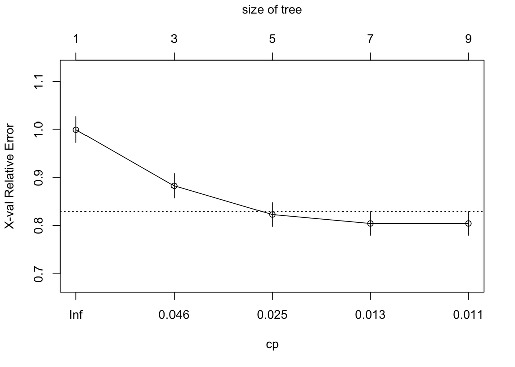

```r
rpart::plotcp(res_cart_cv$learners[[5]]$model)
```

Now, choose a cost penalty and add this as a model to our benchmark set:

```r
lrn_cart_cp <- lrn("classif.rpart", predict_type = "prob", cp = 0.016)

res <- benchmark(data.table(
  task       = list(credit_task),
  learner    = list(lrn_baseline,
                    lrn_cart,
                    lrn_cart_cp),
  resampling = list(cv5)
), store_models = TRUE)
```

```
## INFO  [12:03:50.933] [mlr3]  Benchmark with 15 resampling iterations
## INFO  [12:03:50.942] [mlr3]  Applying learner 'classif.rpart' on task 'BankCredit' (iter 2/5)
## INFO  [12:03:50.984] [mlr3]  Applying learner 'classif.rpart' on task 'BankCredit' (iter 1/5)
## INFO  [12:03:51.017] [mlr3]  Applying learner 'classif.featureless' on task 'BankCredit' (iter 4/5)
## INFO  [12:03:51.027] [mlr3]  Applying learner 'classif.featureless' on task 'BankCredit' (iter 1/5)
## INFO  [12:03:51.039] [mlr3]  Applying learner 'classif.rpart' on task 'BankCredit' (iter 4/5)
## INFO  [12:03:51.072] [mlr3]  Applying learner 'classif.featureless' on task 'BankCredit' (iter 2/5)
## INFO  [12:03:51.083] [mlr3]  Applying learner 'classif.rpart' on task 'BankCredit' (iter 3/5)
## INFO  [12:03:51.120] [mlr3]  Applying learner 'classif.rpart' on task 'BankCredit' (iter 5/5)
## INFO  [12:03:51.150] [mlr3]  Applying learner 'classif.rpart' on task 'BankCredit' (iter 1/5)
## INFO  [12:03:51.179] [mlr3]  Applying learner 'classif.rpart' on task 'BankCredit' (iter 4/5)
## INFO  [12:03:51.209] [mlr3]  Applying learner 'classif.rpart' on task 'BankCredit' (iter 2/5)
## INFO  [12:03:51.248] [mlr3]  Applying learner 'classif.rpart' on task 'BankCredit' (iter 3/5)
## INFO  [12:03:51.282] [mlr3]  Applying learner 'classif.featureless' on task 'BankCredit' (iter 5/5)
## INFO  [12:03:51.292] [mlr3]  Applying learner 'classif.featureless' on task 'BankCredit' (iter 3/5)
## INFO  [12:03:51.304] [mlr3]  Applying learner 'classif.rpart' on task 'BankCredit' (iter 5/5)
## INFO  [12:03:51.338] [mlr3]  Finished benchmark
```

```r
res$aggregate(list(msr("classif.ce"),
                   msr("classif.acc"),
                   msr("classif.auc"),
                   msr("classif.fpr"),
                   msr("classif.fnr")))
```

| nr | resample_result | task_id | learner_id | resampling_id | iters | classif.ce | classif.acc | classif.auc | classif.fpr | classif.fnr |
| --- | --- | --- | --- | --- | --- | --- | --- | --- | --- | --- |
| 1 |  | BankCredit | classif.featureless | cv | 5 | 0.2815415 | 0.7184585 | 0.5000000 | 0.00000000 | 1.0000000 |
| 2 |  | BankCredit | classif.rpart | cv | 5 | 0.2263146 | 0.7736854 | 0.7304518 | 0.08655726 | 0.5835342 |
| 3 |  | BankCredit | classif.rpart | cv | 5 | 0.2357432 | 0.7642568 | 0.6952301 | 0.08133640 | 0.6307500 |

In this case we see a slight improvement to false-positive rate at the cost of higher errors elsewhere. These might be tradeoffs you need to make in the real world.

### Dealing with missingness and factors

To handle missing data and factors, we will need to introduce a modelling pipeline. In this pipeline we need to impute missing values and dummy/one-hot code factors.

Pipelines allow us to create a sophisticated workflow without having to manually code how everything ties together. To see what pipeline operations are available:

```r
# View will open a tab where you can more easily see the detail ...
View(as.data.table(mlr_pipeops))
# ... whilst this just gives the names
mlr_pipeops
```

```
## <DictionaryPipeOp> with 74 stored values
## Keys: boxcox, branch, chunk, classbalancing, classifavg, classweights,
##   colapply, collapsefactors, colroles, compose_crank, compose_distr,
##   compose_probregr, copy, crankcompose, datefeatures, distrcompose,
##   encode, encodeimpact, encodelmer, featureunion, filter, fixfactors,
##   histbin, ica, imputeconstant, imputehist, imputelearner, imputemean,
##   imputemedian, imputemode, imputeoor, imputesample, kernelpca,
##   learner, learner_cv, missind, modelmatrix, multiplicityexply,
##   multiplicityimply, mutate, nmf, nop, ovrsplit, ovrunite, pca, proxy,
##   quantilebin, randomprojection, randomresponse, regravg,
##   removeconstants, renamecolumns, replicate, scale, scalemaxabs,
##   scalerange, select, smote, spatialsign, subsample, survavg,
##   targetinvert, targetmutate, targettrafoscalerange, textvectorizer,
##   threshold, trafopred_regrsurv, trafopred_survregr,
##   trafotask_regrsurv, trafotask_survregr, tunethreshold, unbranch,
##   vtreat, yeojohnson
```

```r
# Again, to see help on any of them, prefix the key name with mlr_pipeops_
?mlr_pipeops_encode
```

So we can see the encode pipeline can do one-hot encoding of factors. We’ll do this first. XGBoost doesn’t accept factors (look back at learners table earlier), so we now create a pipeline operation to encode them before passing to the learner. the function `po()` adds operations and `%>>%` connects the steps

```r
# Create a pipeline which encodes and then fits an XGBoost model
lrn_xgboost <- lrn("classif.xgboost", predict_type = "prob")
pl_xgb <- po("encode") %>>%
  po(lrn_xgboost)

# Now fit as normal ... we can just add it to our benchmark set
res <- benchmark(data.table(
  task       = list(credit_task),
  learner    = list(lrn_baseline,
                    lrn_cart,
                    lrn_cart_cp,
                    pl_xgb),
  resampling = list(cv5)
), store_models = TRUE)
```

[output not shown]

```r
res$aggregate(list(msr("classif.ce"),
                   msr("classif.acc"),
                   msr("classif.fpr"),
                   msr("classif.fnr")))
```

| nr | resample_result | task_id | learner_id | resampling_id | iters | classif.ce | classif.acc | classif.fpr | classif.fnr |
| --- | --- | --- | --- | --- | --- | --- | --- | --- | --- |
| 1 |  | BankCredit | classif.featureless | cv | 5 | 0.2815415 | 0.7184585 | 0.00000000 | 1.0000000 |
| 2 |  | BankCredit | classif.rpart | cv | 5 | 0.2263146 | 0.7736854 | 0.08655726 | 0.5835342 |
| 3 |  | BankCredit | classif.rpart | cv | 5 | 0.2357432 | 0.7642568 | 0.08133640 | 0.6307500 |
| 4 |  | BankCredit | encode.classif.xgboost | cv | 5 | 0.2328282 | 0.7671718 | 0.12284823 | 0.5148356 |

Handling missingness is slightly more involved. We provide a pipeline recipie here which is quite robust … read the documentation of each step to understand more.

We then apply this to logistic regression.

```r
# First create a pipeline of just missing fixes we can later use with models
pl_missing <- po("fixfactors") %>>%
  po("removeconstants") %>>%
  po("imputesample", affect_columns = selector_type(c("ordered", "factor"))) %>>%
  po("imputemean")

# Now try with a model that needs no missingness
lrn_log_reg <- lrn("classif.log_reg", predict_type = "prob")
pl_log_reg <- pl_missing %>>%
  po(lrn_log_reg)

# Now fit as normal ... we can just add it to our benchmark set
res <- benchmark(data.table(
  task       = list(credit_task),
  learner    = list(lrn_baseline,
                    lrn_cart,
                    lrn_cart_cp,
                    pl_xgb,
                    pl_log_reg),
  resampling = list(cv5)
), store_models = TRUE)
```

[output not shown]

```r
res$aggregate(list(msr("classif.ce"),
                   msr("classif.acc"),
                   msr("classif.fpr"),
                   msr("classif.fnr")))
```

| nr | resample_result | task_id | learner_id | resampling_id | iters | classif.ce | classif.acc | classif.fpr | classif.fnr |
| --- | --- | --- | --- | --- | --- | --- | --- | --- | --- |
| 1 |  | BankCredit | classif.featureless | cv | 5 | 0.2815415 | 0.7184585 | 0.00000000 | 1.0000000 |
| 2 |  | BankCredit | classif.rpart | cv | 5 | 0.2263146 | 0.7736854 | 0.08655726 | 0.5835342 |
| 3 |  | BankCredit | classif.rpart | cv | 5 | 0.2357432 | 0.7642568 | 0.08133640 | 0.6307500 |
| 4 |  | BankCredit | encode.classif.xgboost | cv | 5 | 0.2337260 | 0.7662740 | 0.12348416 | 0.5164229 |
| 5 |  | BankCredit | fixfactors.removeconstants.imputesample.imputemean.classif.log_reg | cv | 5 | 0.2045388 | 0.7954612 | 0.08627687 | 0.5071663 |

### Advanced: super learning

Rather than having to choose among the models that we fitted above, we could instead fit all of them and have a final “super learner” fitted which automatically selects the best prediction based on the available base learners. We can do this using the pipelines in MLR3 …

We start from scratch to make this more advanced example self contained.

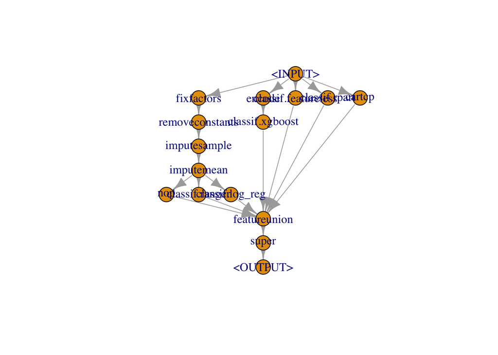

```r
library("data.table")
library("mlr3verse")

set.seed(212) # set seed for reproducibility

# Load data
data("credit_data", package = "modeldata")

# Define task
credit_task <- TaskClassif$new(id = "BankCredit",
                               backend = credit_data,
                               target = "Status",
                               positive = "bad")

# Cross validation resampling strategy
cv5 <- rsmp("cv", folds = 5)
cv5$instantiate(credit_task)

# Define a collection of base learners
lrn_baseline <- lrn("classif.featureless", predict_type = "prob")
lrn_cart     <- lrn("classif.rpart", predict_type = "prob")
lrn_cart_cp  <- lrn("classif.rpart", predict_type = "prob", cp = 0.016, id = "cartcp")
lrn_ranger   <- lrn("classif.ranger", predict_type = "prob")
lrn_xgboost  <- lrn("classif.xgboost", predict_type = "prob")
lrn_log_reg  <- lrn("classif.log_reg", predict_type = "prob")

# Define a super learner
lrnsp_log_reg <- lrn("classif.log_reg", predict_type = "prob", id = "super")

# Missingness imputation pipeline
pl_missing <- po("fixfactors") %>>%
  po("removeconstants") %>>%
  po("imputesample", affect_columns = selector_type(c("ordered", "factor"))) %>>%
  po("imputemean")

# Factors coding pipeline
pl_factor <- po("encode")

# Now define the full pipeline
spr_lrn <- gunion(list(
  # First group of learners requiring no modification to input
  gunion(list(
    po("learner_cv", lrn_baseline),
    po("learner_cv", lrn_cart),
    po("learner_cv", lrn_cart_cp)
  )),
  # Next group of learners requiring special treatment of missingness
  pl_missing %>>%
    gunion(list(
      po("learner_cv", lrn_ranger),
      po("learner_cv", lrn_log_reg),
      po("nop") # This passes through the original features adjusted for
                # missingness to the super learner
    )),
  # Last group needing factor encoding
  pl_factor %>>%
    po("learner_cv", lrn_xgboost)
)) %>>%
  po("featureunion") %>>%
  po(lrnsp_log_reg)

# This plot shows a graph of the learning pipeline
spr_lrn$plot()
```

```r
# Finally fit the base learners and super learner and evaluate
res_spr <- resample(credit_task, spr_lrn, cv5, store_models = TRUE)
```

[output not shown]

[output cut: 60 more lines]

[output not shown]

```r
res_spr$aggregate(list(msr("classif.ce"),
                       msr("classif.acc"),
                       msr("classif.fpr"),
                       msr("classif.fnr")))
```

```
##  classif.ce classif.acc classif.fpr classif.fnr
##  0.20049509  0.79950491  0.09940729  0.45903074
```

You will note these are the best results achieved of all the learners (except in false positive), albeit that this is by far the most complicated model